# Lab Notebook

Tennessee Hickling, Ben Griffiths, Josh Givens

11/01/2022

This report makes use of the `tennisprediction` package which can be found [here](https://github.com/Tennessee-Wallaceh/tennisprediction.git) or installed using the following command. `devtools::install_github("https://github.com/Tennessee-Wallaceh/tennisprediction.git")`.

An HTML version of this report (with the option to download source code) can also be found [here](https://joshgivens.github.io/tennisprediction/)

```r
library(tennisprediction)
library(dplyr)
library(tidyr)
library(magrittr)
library(tibble)
library(ggplot2)
library(ROCR)
library(knitr)
```

# Pipeline Analysis

## Data Preparation

Load and prepare the data.

```r
sample_data = load_years(c('2013', '2014', '2015', '2016', '2017'))
```

```
## Retrieving 2013 season locally ...
## Retrieving 2014 season locally ...
## Retrieving 2015 season locally ...
## Retrieving 2016 season locally ...
## Retrieving 2017 season locally ...
```

```r
sample_data %<>%
  mutate(Wgames=colSums(rbind(W1,W2,W3,W4,W5), na.rm=TRUE),
         Lgames=colSums(rbind(L1,L2,L3,L4,L5), na.rm=TRUE),
         Tgames=Wgames+Lgames, var_1=1) %>%
  tibble::rowid_to_column("match_id")
```

## Set up and run pipeline

First we create a list of estimators which we will want to use in our prediction. Then we use the `run_pipeline` function to, at each tournament, fit the models on all previous tournaments in data and then predict the current tournament.

```r
estimators = list(
  '1yr Naive'=new('NaiveEstimator', years_of_data=1),
  'bookies'=new('BookiesEstimator'),
  'Bradley-Terry'=new('BradleyTerryEstimator'),
   # Note: the validated estimator significantly reduces performance. (~1m per fit)
  'Bradley-Terry-V'=new(
    'BradleyTerryEstimator_CV',
    court_weight_list=list(
      get_court_weights(0.7, 0.7, 0.7),
      get_court_weights(0.65, 0.65, 0.65),
      get_court_weights(0.6, 0.6, 0.6),
      get_court_weights(0.5, 0.5, 0.5)
    ),
    half_life_list=list(400, 365, 330),
  )
)

# Run pipeline to gather metrics
analysis_table = NULL
for (estimator in names(estimators)) {
  print(glue::glue('Running pipeline for {estimator}...'))
  analysis_output = run_pipeline(
    sample_data,
    estimators[[estimator]],
    batch_kind='Month',
    verbose=F
  )

  analysis_table %<>%
    bind_rows(analysis_output %>% add_column(estimator=estimator))
}
```

```
## Running pipeline for 1yr Naive...
## Pipeline Date: 2012-12-01
## Pipeline Date: 2013-01-01
## Pipeline Date: 2013-02-01
## Pipeline Date: 2013-03-01
## Pipeline Date: 2013-04-01
## Pipeline Date: 2013-05-01
## Pipeline Date: 2013-06-01
## Pipeline Date: 2013-07-01
## Pipeline Date: 2013-08-01
## Pipeline Date: 2013-09-01
## Pipeline Date: 2013-10-01
## Pipeline Date: 2013-11-01
## Pipeline Date: 2013-12-01
## Pipeline Date: 2014-01-01
## Pipeline Date: 2014-02-01
## Pipeline Date: 2014-03-01
## Pipeline Date: 2014-04-01
## Pipeline Date: 2014-05-01
## Pipeline Date: 2014-06-01
## Pipeline Date: 2014-07-01
## Pipeline Date: 2014-08-01
## Pipeline Date: 2014-09-01
## Pipeline Date: 2014-10-01
## Pipeline Date: 2014-11-01
## Pipeline Date: 2015-01-01
## Pipeline Date: 2015-02-01
## Pipeline Date: 2015-03-01
## Pipeline Date: 2015-04-01
## Pipeline Date: 2015-05-01
## Pipeline Date: 2015-06-01
## Pipeline Date: 2015-07-01
## Pipeline Date: 2015-08-01
## Pipeline Date: 2015-09-01
## Pipeline Date: 2015-10-01
## Pipeline Date: 2015-11-01
## Pipeline Date: 2016-01-01
## Pipeline Date: 2016-02-01
## Pipeline Date: 2016-03-01
## Pipeline Date: 2016-04-01
```

[output cut: 177 more lines]

```
## Pipeline Date: 2016-08-01
## Pipeline Date: 2016-09-01
## Pipeline Date: 2016-10-01
## Pipeline Date: 2016-11-01
## Pipeline Date: 2017-01-01
## Pipeline Date: 2017-02-01
## Pipeline Date: 2017-03-01
## Pipeline Date: 2017-04-01
## Pipeline Date: 2017-05-01
## Pipeline Date: 2017-06-01
## Pipeline Date: 2017-07-01
## Pipeline Date: 2017-08-01
## Pipeline Date: 2017-09-01
## Pipeline Date: 2017-10-01
## Pipeline Date: 2017-11-01
```

## Clean the predictions and prepare data

We now tidy our analysis table to prepare it for obtaining metrics on our predictive ability.

```r
predictions = prepare_predictions(analysis_table)
```

# Accuracy Analysis

Next we obtain information on the accuracy, log-likelihood, and AUC of each of our estimators.

```r
predictions %>%
  group_by(estimator) %>%
  summarise(
    accuracy=metric.accuracy(predicted_probability, labels, cutoff=0.5),
    auc=metric.auc(predicted_probability, labels),
    ll=metric.log_likelihood(predicted_probability, labels)
  ) %>%
  kable()
```

| estimator | accuracy | auc | ll |
| --- | --- | --- | --- |
| 1yr Naive | 0.6474958 | 0.6092212 | -9941.497 |
| bookies | 0.6907643 | 0.7041763 | -7461.087 |
| Bradley-Terry | 0.6591362 | 0.6280308 | -8528.981 |
| Bradley-Terry-V | 0.6634247 | 0.6342562 | -8460.110 |

## Accuracy Over Time

We now plot the accuracy of our estimators at each tournament and plot these accuracies over time.

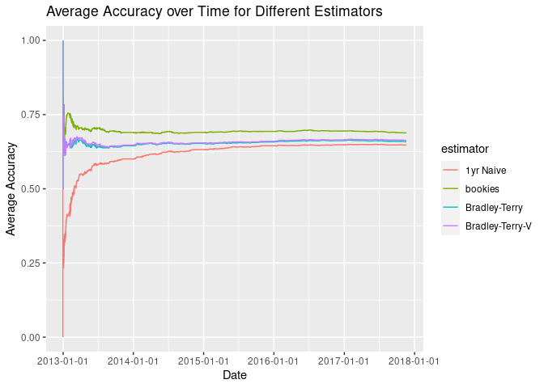

```r
plot = ggplot() +
  geom_line(
    data=predictions %>%
      group_by(estimator) %>%
      mutate(position=1:n()) %>%
      mutate(accuracy=cumsum(winner_probability > loser_probability) / position),
    aes(
      x=Date,
      y=accuracy,
      colour=estimator
    ),
  ) +
  ylab('Average Accuracy') +
  ggtitle('Average Accuracy over Time for Different Estimators')+
  scale_x_datetime(date_breaks = "years")

print(plot)
```

## Precision-Recall

We now produce a precision-recall plot for each of our estimators.

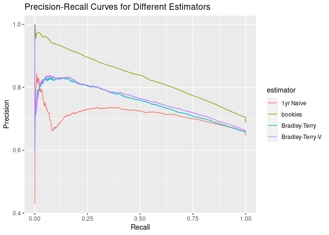

```r
plot = ggplot() +
  geom_line(
    data=predictions %>%
      group_by(estimator) %>%
      summarize(
        Recall=performance(prediction(predicted_probability, labels), "prec", "rec")@x.values[[1]],
        Precision=performance(prediction(predicted_probability, labels), "prec", "rec")@y.values[[1]]
      ),
    aes(
      x=Recall,
      y=Precision,
      colour=estimator
    ),
  ) +
  ggtitle('Precision-Recall Curves for Different Estimators')

print(plot)
```

# Stratified Analysis

In the stratified analysis we break our data into various subgroups and determine the efficacy of our estimators on each of these subgroups.

## Top Ten

```r
top_ten_predictions = predictions %>%
  left_join(
    sample_data %>%
      select(match_id, WRank, LRank) %>%
      mutate(top_ten=WRank < 11 | LRank < 11),
    by='match_id'
  ) %>%
  filter(top_ten)

top_ten_predictions %>%
  group_by(estimator) %>%
  summarise(
    accuracy=metric.accuracy(predicted_probability, labels, cutoff=0.5),
    auc=metric.auc(predicted_probability, labels),
    ll=metric.log_likelihood(predicted_probability, labels)
  ) %>%
kable()
```

| estimator | accuracy | auc | ll |
| --- | --- | --- | --- |
| 1yr Naive | 0.7956722 | 0.6595941 | -1666.583 |
| bookies | 0.8048954 | 0.7353373 | -1257.590 |
| Bradley-Terry | 0.7999291 | 0.6744386 | -1358.863 |
| Bradley-Terry-V | 0.8006385 | 0.6791591 | -1347.094 |

## By Court

We next split our predictions by court type and obtain the log-likelihood, AUC, and accuracy for each estimator on each court type.

```r
predictions %>%
  left_join(sample_data %>% select(match_id, Surface), by='match_id') %>%
  group_by(estimator, Surface) %>%
  summarise(
    accuracy=metric.accuracy(predicted_probability, labels, cutoff=0.5),
    auc=metric.auc(predicted_probability, labels),
    ll=metric.log_likelihood(predicted_probability, labels)
  ) %>%
  kable()
```

| estimator | Surface | accuracy | auc | ll |
| --- | --- | --- | --- | --- |
| 1yr Naive | Clay | 0.6386413 | 0.6099507 | -3175.9854 |
| 1yr Naive | Grass | 0.6463415 | 0.5907684 | -1236.7131 |
| 1yr Naive | Hard | 0.6527419 | 0.6136239 | -5528.7987 |
| bookies | Clay | 0.6824861 | 0.7027916 | -2403.4682 |
| bookies | Grass | 0.7079589 | 0.7110912 | -865.7194 |
| bookies | Hard | 0.6917948 | 0.7033128 | -4191.8990 |
| Bradley-Terry | Clay | 0.6451457 | 0.6215322 | -2713.5662 |
| Bradley-Terry | Grass | 0.6566110 | 0.6307443 | -1019.0422 |
| Bradley-Terry | Hard | 0.6675738 | 0.6308525 | -4796.3726 |
| Bradley-Terry-V | Clay | 0.6567092 | 0.6260163 | -2671.8500 |
| Bradley-Terry-V | Grass | 0.6501926 | 0.6483404 | -1019.0315 |
| Bradley-Terry-V | Hard | 0.6700231 | 0.6358104 | -4769.2284 |

# Bookmakers Edge

Finally, we plot a histogram of the bookmaker’s edge across all matches. The Bookmakers edge a statistic which for each game defines how much the odds penalise a punter. Higher values equate to harsher penalisations.

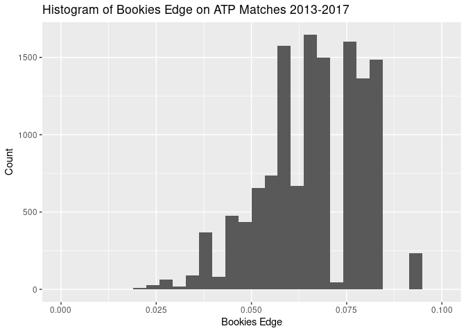

```r
sample_data %>%
  mutate(
    B365W=ifelse(is.na(B365W), 1000, B365W),
    B365L=ifelse(is.na(B365L), 1000, B365L)
  ) %>%
  mutate(
    winner_probability=1 / B365W,
    loser_probability=1 / B365L,
    bookies_edge=winner_probability + loser_probability - 1
  ) %>%
  ggplot() +
  geom_histogram(aes(x=bookies_edge)) +
  xlim(c(0, 0.1)) +
  ggtitle('Histogram of Bookies Edge on ATP Matches 2013-2017') +
  xlab('Bookies Edge') +
  ylab('Count')
```